# Vaccines: Many Beliefs Pilot 3

# Scale Internal Consistency Reliability

Below are computed chronbach’s alpha for all scales along with more detailed analyses of scales that are problematic.

## Holistic Balance

```r
hb <- c("hb_hb_1",
"hb_hb_2",
"hb_hb_3",
"hb_hb_4")
hb.alpha <- psych::alpha(df[,hb])
hb.alpha$total$raw_alpha
```

```
[1] 0.8245148
```

## Naturalism

```r
nat <- c("nat_nat_1",
"nat_nat_2r",
"nat_nat_3",
"nat_nat_4",
"nat_nat_5")
naturalism.alpha <- psych::alpha(df[,nat])
naturalism.alpha$total$raw_alpha
```

```
[1] 0.825029
```

## Disease Rarity

**NOTE**: we previously scored this one kind of strangely, so it’s now been relabeld as “diseaseRare” to indicate that it reflects participants’ belief the diseases are extremely rare.

```r
diseaseRare <- c("diseaseRare_diseaseRare_1",
"diseaseRare_diseaseRare_2",
"diseaseRare_diseaseRare_3",
"diseaseRare_diseaseRare_4")
diseaseRare.alpha <- psych::alpha(df[,diseaseRare])
diseaseRare.alpha$total$raw_alpha
```

```
[1] 0.8396417
```

## Disease Severity

Disease severe is now a highly reliable scale (and could even remove an item.)

```r
diseaseSevere <- c("diseaseSevere_diseaseSevere_1",
"diseaseSevere_diseaseSevere_2",
"diseaseSevere_diseaseSevere_3",
"diseaseSevere_diseaseSevere_4r",
"diseaseSevere_diseaseSevere_5",
"diseaseSevere_diseaseSevere_6")
diseaseSevere.alpha <- psych::alpha(df[,diseaseSevere])
diseaseSevere.alpha$total$raw_alpha
```

```
[1] 0.8686574
```

```r
diseaseSevere.alpha
```

```
Reliability analysis
Call: psych::alpha(x = df[, diseaseSevere])

  raw_alpha std.alpha G6(smc) average_r S/N  ase mean  sd
      0.87      0.87    0.86      0.53 6.8 0.02  5.4 1.1

 lower alpha upper     95% confidence boundaries
0.83 0.87 0.91

 Reliability if an item is dropped:
                               raw_alpha std.alpha G6(smc) average_r S/N alpha se
diseaseSevere_diseaseSevere_1       0.83      0.83    0.81      0.50 5.0    0.027
diseaseSevere_diseaseSevere_2       0.86      0.86    0.84      0.55 6.1    0.023
diseaseSevere_diseaseSevere_3       0.86      0.87    0.85      0.57 6.5    0.022
diseaseSevere_diseaseSevere_4r      0.85      0.85    0.84      0.53 5.7    0.024
diseaseSevere_diseaseSevere_5       0.83      0.83    0.81      0.50 4.9    0.027
diseaseSevere_diseaseSevere_6       0.85      0.85    0.83      0.53 5.7    0.024

 Item statistics
                                n raw.r std.r r.cor r.drop mean  sd
diseaseSevere_diseaseSevere_1  98  0.84  0.84  0.82   0.76  5.5 1.3
diseaseSevere_diseaseSevere_2  98  0.75  0.74  0.66   0.61  4.7 1.5
diseaseSevere_diseaseSevere_3  98  0.69  0.70  0.61   0.57  5.2 1.3
diseaseSevere_diseaseSevere_4r 98  0.79  0.78  0.71   0.67  5.4 1.6
diseaseSevere_diseaseSevere_5  98  0.85  0.85  0.83   0.77  5.7 1.4
diseaseSevere_diseaseSevere_6  98  0.76  0.77  0.72   0.65  5.8 1.3

Non missing response frequency for each item
                                  1    2    3    4    5    6    7 miss
diseaseSevere_diseaseSevere_1  0.01 0.00 0.06 0.17 0.14 0.36 0.26    0
diseaseSevere_diseaseSevere_2  0.03 0.05 0.11 0.26 0.21 0.23 0.10    0
diseaseSevere_diseaseSevere_3  0.01 0.04 0.03 0.19 0.24 0.34 0.14    0
diseaseSevere_diseaseSevere_4r 0.03 0.04 0.07 0.12 0.12 0.33 0.29    0
diseaseSevere_diseaseSevere_5  0.01 0.05 0.00 0.11 0.15 0.35 0.33    0
diseaseSevere_diseaseSevere_6  0.01 0.01 0.04 0.09 0.17 0.32 0.36    0
```

### Diagnosing

Here are histograms of each item

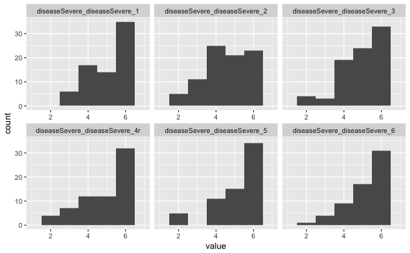

```r
library(ggplot2)
library(reshape2)
ggplot(data = melt(df[,diseaseSevere]), mapping = aes(x = value)) +
    geom_histogram(bins = 7) + facet_wrap(~variable, scales = 'free_x') + xlim(1,7)
```

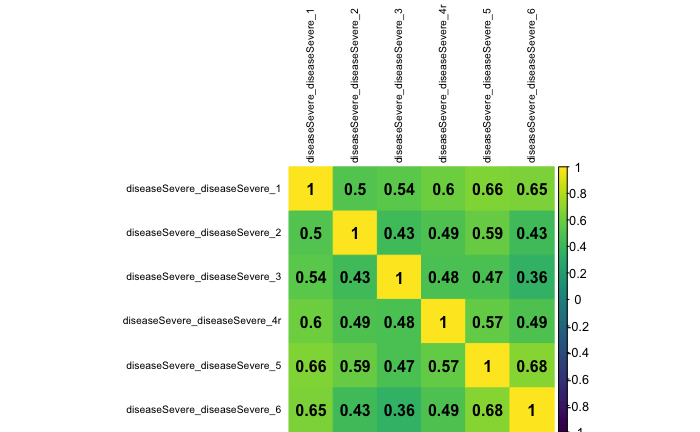

```r
corrplot(cor(df[,diseaseSevere]),
         order="alpha",
         tl.cex=.65,
         tl.col="black",
         method="color",
         addCoef.col="black",
         col=viridis(128))
```

## Vaccine Effectiveness

```r
vaccEff <- c("vaccEff_vaccEff_1",
"vaccEff_vaccEff_2r",
"vaccEff_vaccEff_3r",
"vaccEff_vaccEff_4")
vaccEff.alpha <- psych::alpha(df[,vaccEff])
vaccEff.alpha$total$raw_alpha
```

```
[1] 0.831754
```

## Vaccine Danger

```r
vaccDanger <- c("vaccDanger_vaccDanger_1",
"vaccDanger_vaccDanger_2",
"vaccDanger_vaccDanger_3",
"vaccDanger_vaccDanger_4r")
vaccDanger.alpha <- psych::alpha(df[,vaccDanger])
vaccDanger.alpha$total$raw_alpha
```

```
[1] 0.8499971
```

## Vaccines are toxic

```r
vaccTox <- c("vaccTox_vaccTox_1",
"vaccTox_vaccTox_2",
"vaccTox_vaccTox_3",
"vaccTox_vaccTox_4r")
vaccTox.alpha <- psych::alpha(df[,vaccTox])
vaccTox.alpha$total$raw
```

```
[1] 0.8889167
```

## Medical Skepticism

```r
medSkept <- c("medSkept_medSkept_1",
"medSkept_medSkept_2r",
#"medSkept_medSkept_3", # planned to remove
"medSkept_medSkept_4",
"medSkept_medSkept_5",
"medSkept_medSkept_6")
medSkept.alpha <- psych::alpha(df[,medSkept])
medSkept.alpha$total$raw_alpha
```

```
[1] 0.7678659
```

```r
medSkept.alpha
```

```
Reliability analysis
Call: psych::alpha(x = df[, medSkept])

  raw_alpha std.alpha G6(smc) average_r S/N   ase mean  sd
      0.77      0.77    0.76      0.39 3.3 0.036    4 1.2

 lower alpha upper     95% confidence boundaries
0.7 0.77 0.84

 Reliability if an item is dropped:
                     raw_alpha std.alpha G6(smc) average_r S/N alpha se
medSkept_medSkept_1       0.74      0.74    0.71      0.41 2.8    0.042
medSkept_medSkept_2r      0.76      0.76    0.75      0.45 3.2    0.039
medSkept_medSkept_4       0.65      0.65    0.60      0.32 1.9    0.057
medSkept_medSkept_5       0.72      0.71    0.68      0.38 2.5    0.045
medSkept_medSkept_6       0.74      0.74    0.72      0.41 2.8    0.042

 Item statistics
                      n raw.r std.r r.cor r.drop mean  sd
medSkept_medSkept_1  98  0.70  0.69  0.58   0.50  4.9 1.7
medSkept_medSkept_2r 98  0.59  0.63  0.47   0.41  2.9 1.4
medSkept_medSkept_4  98  0.85  0.85  0.84   0.73  3.6 1.8
medSkept_medSkept_5  98  0.73  0.74  0.67   0.56  3.3 1.6
medSkept_medSkept_6  98  0.71  0.69  0.57   0.50  5.1 1.8

Non missing response frequency for each item
                        1    2    3    4    5    6    7 miss
medSkept_medSkept_1  0.05 0.08 0.06 0.11 0.34 0.15 0.20    0
medSkept_medSkept_2r 0.18 0.20 0.34 0.16 0.07 0.02 0.02    0
medSkept_medSkept_4  0.14 0.19 0.14 0.15 0.22 0.09 0.05    0
medSkept_medSkept_5  0.16 0.18 0.18 0.23 0.13 0.08 0.02    0
medSkept_medSkept_6  0.05 0.05 0.11 0.11 0.14 0.28 0.26    0
```

## Vaccination Intentions

```r
vaccIntent <- c("vaccIntent_vaccIntent_1r",
"vaccIntent_vaccIntent_2",
"vaccIntent_vaccIntent_3r",
"vaccIntent_vaccIntent_4",
"vaccIntent_vaccIntent_5r")
vaccIntent.alpha <- psych::alpha(df[,vaccIntent])
vaccIntent.alpha$total$raw_alpha
```

```
[1] 0.8304273
```

## Parental Expertise

Success!

```r
parExpert <- c("parentExpert_parentExpert_1",
"parentExpert_parentExpert_2",
"parentExpert_parentExpert_3",
"parentExpert_parentExpert_4r")
parExpert.alpha <- psych::alpha(df[,parExpert])
parExpert.alpha$total$raw_alpha
```

```
[1] 0.8518632
```

```r
parExpert.alpha
```

```
Reliability analysis
Call: psych::alpha(x = df[, parExpert])

  raw_alpha std.alpha G6(smc) average_r S/N   ase mean  sd
      0.85      0.85    0.83      0.59 5.8 0.024  3.4 1.4

 lower alpha upper     95% confidence boundaries
0.8 0.85 0.9

 Reliability if an item is dropped:
                             raw_alpha std.alpha G6(smc) average_r S/N alpha se
parentExpert_parentExpert_1       0.83      0.83    0.78      0.62 4.9    0.029
parentExpert_parentExpert_2       0.78      0.78    0.71      0.55 3.6    0.038
parentExpert_parentExpert_3       0.80      0.80    0.73      0.58 4.1    0.034
parentExpert_parentExpert_4r      0.83      0.83    0.79      0.62 4.9    0.030

 Item statistics
                              n raw.r std.r r.cor r.drop mean  sd
parentExpert_parentExpert_1  98  0.81  0.80  0.70   0.65  4.1 1.7
parentExpert_parentExpert_2  98  0.88  0.87  0.84   0.76  3.4 1.7
parentExpert_parentExpert_3  98  0.84  0.85  0.79   0.71  2.9 1.6
parentExpert_parentExpert_4r 98  0.80  0.81  0.70   0.65  3.3 1.5

Non missing response frequency for each item
                                1    2    3    4    5    6    7 miss
parentExpert_parentExpert_1  0.14 0.05 0.09 0.24 0.28 0.12 0.07    0
parentExpert_parentExpert_2  0.20 0.13 0.20 0.14 0.20 0.08 0.03    0
parentExpert_parentExpert_3  0.24 0.22 0.18 0.15 0.14 0.04 0.01    0
parentExpert_parentExpert_4r 0.13 0.19 0.26 0.19 0.14 0.05 0.03    0
```

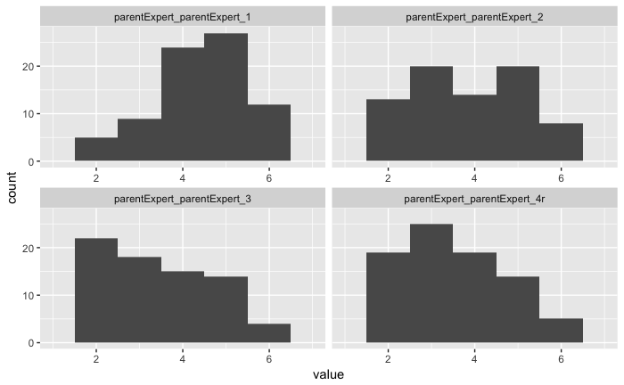

```r
library(ggplot2)
library(reshape2)
ggplot(data = melt(df[,parExpert]), mapping = aes(x = value)) +
    geom_histogram(bins = 7) + facet_wrap(~variable, scales = 'free_x') + xlim(1,7)
```

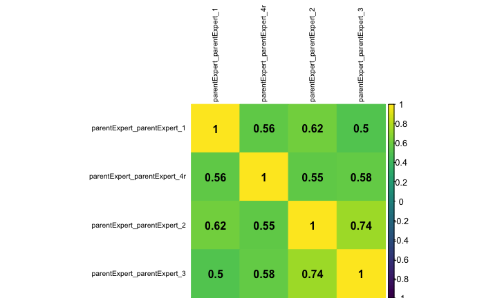

```r
corrplot(cor(df[,parExpert]),
         order="AOE",
         tl.cex=.65,
         tl.col="black",
         method="color",
         addCoef.col="black",
         col=viridis(128))
```

## Infant immune system has limited capacity

Reliability is still weak Might improve if we ditch my new item #5

```r
immCap <- c(
  "infantImmLimCap_infantImmLimCap_1",
"infantImmLimCap_infantImmLimCap_2r",
"infantImmLimCap_infantImmLimCap_3",
"infantImmLimCap_infantImmLimCap_4",
"infantImmLimCap_infantImmLimCap_5")
immCap.alpha <- psych::alpha(df[,immCap])
immCap.alpha$total$raw_alpha
```

```
[1] 0.7647481
```

```r
immCap.alpha
```

```
Reliability analysis
Call: psych::alpha(x = df[, immCap])

  raw_alpha std.alpha G6(smc) average_r S/N   ase mean sd
      0.76      0.76    0.75      0.39 3.2 0.037  4.1  1

 lower alpha upper     95% confidence boundaries
0.69 0.76 0.84

 Reliability if an item is dropped:
                                   raw_alpha std.alpha G6(smc) average_r S/N alpha se
infantImmLimCap_infantImmLimCap_1       0.70      0.69    0.66      0.36 2.2    0.049
infantImmLimCap_infantImmLimCap_2r      0.72      0.72    0.68      0.39 2.5    0.044
infantImmLimCap_infantImmLimCap_3       0.71      0.71    0.67      0.38 2.4    0.047
infantImmLimCap_infantImmLimCap_4       0.68      0.68    0.64      0.35 2.1    0.052
infantImmLimCap_infantImmLimCap_5       0.78      0.78    0.75      0.47 3.6    0.036

 Item statistics
                                    n raw.r std.r r.cor r.drop mean  sd
infantImmLimCap_infantImmLimCap_1  98  0.77  0.77  0.70   0.61  4.6 1.4
infantImmLimCap_infantImmLimCap_2r 98  0.71  0.72  0.62   0.53  3.8 1.3
infantImmLimCap_infantImmLimCap_3  98  0.74  0.73  0.65   0.57  4.1 1.4
infantImmLimCap_infantImmLimCap_4  98  0.81  0.78  0.73   0.63  4.4 1.6
infantImmLimCap_infantImmLimCap_5  98  0.55  0.58  0.38   0.34  3.3 1.3

Non missing response frequency for each item
                                      1    2    3    4    5    6    7 miss
infantImmLimCap_infantImmLimCap_1  0.04 0.05 0.08 0.26 0.29 0.23 0.05    0
infantImmLimCap_infantImmLimCap_2r 0.05 0.08 0.27 0.30 0.22 0.04 0.04    0
infantImmLimCap_infantImmLimCap_3  0.05 0.10 0.14 0.34 0.20 0.13 0.03    0
infantImmLimCap_infantImmLimCap_4  0.06 0.05 0.15 0.26 0.19 0.17 0.11    0
infantImmLimCap_infantImmLimCap_5  0.06 0.22 0.26 0.31 0.12 0.01 0.02    0
```

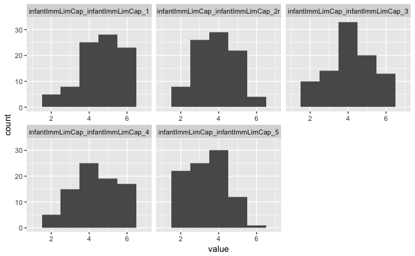

```r
library(ggplot2)
library(reshape2)
ggplot(data = melt(df[,immCap]), mapping = aes(x = value)) +
    geom_histogram(bins = 7) + facet_wrap(~variable, scales = 'free_x') + xlim(1,7)
```

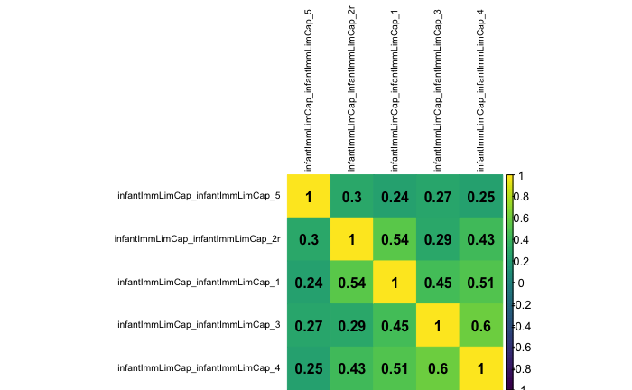

```r
corrplot(cor(df[,immCap]),
         order="AOE",
         tl.cex=.65,
         tl.col="black",
         method="color",
         addCoef.col="black",
         col=viridis(128))
```

## Immune system produces cold symptoms

Reliability actually got worse!

```r
immSympt <- c("immSympt_immSympt_1",
"immSympt_immSympt_2r",
"immSympt_immSympt_3r",
"immSympt_immSympt_4",
"immSympt_immSympt_5r",
"immSympt_immSympt_6",
"immSympt_immSympt_7r")
immSympt.alpha <- psych::alpha(df[,immSympt])
immSympt.alpha$total$raw_alpha
```

```
[1] 0.6699193
```

```r
immSympt.alpha
```

```
Reliability analysis
Call: psych::alpha(x = df[, immSympt])

  raw_alpha std.alpha G6(smc) average_r S/N   ase mean   sd
      0.67      0.68     0.7      0.23 2.1 0.051    3 0.81

 lower alpha upper     95% confidence boundaries
0.57 0.67 0.77

 Reliability if an item is dropped:
                     raw_alpha std.alpha G6(smc) average_r S/N alpha se
immSympt_immSympt_1       0.64      0.65    0.67      0.23 1.8    0.057
immSympt_immSympt_2r      0.60      0.60    0.62      0.20 1.5    0.063
immSympt_immSympt_3r      0.64      0.64    0.64      0.23 1.8    0.057
immSympt_immSympt_4       0.66      0.67    0.67      0.25 2.0    0.053
immSympt_immSympt_5r      0.67      0.67    0.66      0.26 2.1    0.051
immSympt_immSympt_6       0.59      0.61    0.62      0.21 1.6    0.064
immSympt_immSympt_7r      0.63      0.64    0.65      0.23 1.8    0.058

 Item statistics
                      n raw.r std.r r.cor r.drop mean  sd
immSympt_immSympt_1  98  0.58  0.57  0.44   0.36  2.6 1.5
immSympt_immSympt_2r 98  0.67  0.69  0.62   0.51  2.8 1.3
immSympt_immSympt_3r 98  0.56  0.58  0.48   0.36  2.5 1.3
immSympt_immSympt_4  98  0.54  0.50  0.38   0.29  3.7 1.6
immSympt_immSympt_5r 98  0.47  0.49  0.37   0.25  2.9 1.4
immSympt_immSympt_6  98  0.69  0.67  0.62   0.51  3.6 1.5
immSympt_immSympt_7r 98  0.58  0.59  0.49   0.39  3.0 1.3

Non missing response frequency for each item
                        1    2    3    4    5    6    7 miss
immSympt_immSympt_1  0.23 0.37 0.16 0.10 0.08 0.03 0.02    0
immSympt_immSympt_2r 0.16 0.27 0.32 0.16 0.07 0.01 0.01    0
immSympt_immSympt_3r 0.29 0.29 0.18 0.19 0.02 0.03 0.00    0
immSympt_immSympt_4  0.08 0.14 0.27 0.22 0.12 0.10 0.06    0
immSympt_immSympt_5r 0.17 0.26 0.26 0.18 0.10 0.02 0.01    0
immSympt_immSympt_6  0.08 0.18 0.17 0.32 0.15 0.06 0.03    0
immSympt_immSympt_7r 0.10 0.28 0.31 0.21 0.06 0.02 0.02    0
```

No obvious fixes here – just a mess.

```r
# library(ggplot2)
# library(reshape2)
#
# ggplot(data = melt(df[,immSympt]), mapping = aes(x = value)) +
#     geom_histogram(bins = 7) + facet_wrap(~variable, scales = 'free_x') + xlim(1,7)
#
# corrplot(cor(df[,immSympt]),
#          order="AOE",
#          tl.cex=.65,
#          tl.col="black",
#          method="color",
#          addCoef.col="black",
#          col=viridis(128))
```

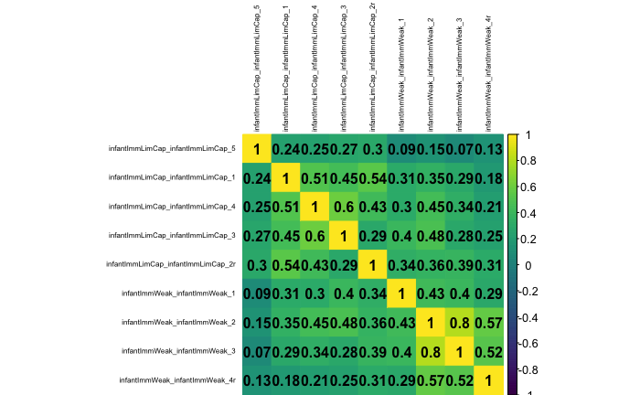

```r
library(ggplot2)
library(reshape2)
# ggplot(data = melt(df[,immSympt]), mapping = aes(x = value)) +
#     geom_histogram(bins = 7) + facet_wrap(~variable, scales = 'free_x') + xlim(1,7)
corrplot(cor(df[,c(immCap,immWeak)]),
         order="AOE",
         tl.cex=.5,
         tl.col="black",
         method="color",
         addCoef.col="black",
         col=viridis(128))
```

## Infants’ immune systems are weak

Looks pretty good.

```r
immWeak <- c("infantImmWeak_infantImmWeak_1",
"infantImmWeak_infantImmWeak_2",
"infantImmWeak_infantImmWeak_3",
"infantImmWeak_infantImmWeak_4r")
immWeak.alpha <- psych::alpha(df[,immWeak])
immWeak.alpha$total$raw_alpha
```

```
[1] 0.8020585
```

```r
immWeak.alpha
```

```
Reliability analysis
Call: psych::alpha(x = df[, immWeak])

  raw_alpha std.alpha G6(smc) average_r S/N   ase mean  sd
       0.8       0.8    0.79       0.5   4 0.033  4.5 1.2

 lower alpha upper     95% confidence boundaries
0.74 0.8 0.87

 Reliability if an item is dropped:
                               raw_alpha std.alpha G6(smc) average_r S/N alpha se
infantImmWeak_infantImmWeak_1       0.84      0.84    0.80      0.63 5.1    0.029
infantImmWeak_infantImmWeak_2       0.67      0.67    0.59      0.40 2.0    0.058
infantImmWeak_infantImmWeak_3       0.69      0.69    0.63      0.43 2.2    0.054
infantImmWeak_infantImmWeak_4r      0.78      0.78    0.76      0.54 3.6    0.039

 Item statistics
                                n raw.r std.r r.cor r.drop mean  sd
infantImmWeak_infantImmWeak_1  98  0.67  0.67  0.47   0.43  4.7 1.5
infantImmWeak_infantImmWeak_2  98  0.89  0.88  0.88   0.78  4.7 1.5
infantImmWeak_infantImmWeak_3  98  0.87  0.86  0.84   0.73  4.7 1.6
infantImmWeak_infantImmWeak_4r 98  0.74  0.75  0.61   0.55  4.1 1.5

Non missing response frequency for each item
                                  1    2    3    4    5    6    7 miss
infantImmWeak_infantImmWeak_1  0.03 0.05 0.15 0.19 0.24 0.21 0.11    0
infantImmWeak_infantImmWeak_2  0.01 0.08 0.14 0.19 0.30 0.10 0.17    0
infantImmWeak_infantImmWeak_3  0.02 0.11 0.10 0.21 0.21 0.17 0.16    0
infantImmWeak_infantImmWeak_4r 0.01 0.13 0.26 0.24 0.17 0.11 0.07    0
```

## Vaccines strain the immune system

Now with five items this makes for a very reliable scale.

```r
vaccStrain <- c("vaccStrain_vaccStrain_1",
"vaccStrain_vaccStrain_2r",
"vaccStrain_vaccStrain_3",
"vaccStrain_vaccStrain_4",
"vaccStrain_vaccStrain_5")
# cor(df$immStrain_1,df$immStrain_2r)
vaccStrain.alpha <- psych::alpha(df[,vaccStrain])
vaccStrain.alpha
```

```
Reliability analysis
Call: psych::alpha(x = df[, vaccStrain])

  raw_alpha std.alpha G6(smc) average_r S/N   ase mean  sd
      0.84      0.84    0.85       0.5 5.1 0.025  3.5 1.3

 lower alpha upper     95% confidence boundaries
0.79 0.84 0.89

 Reliability if an item is dropped:
                         raw_alpha std.alpha G6(smc) average_r  S/N alpha se
vaccStrain_vaccStrain_1       0.78      0.78    0.79      0.47  3.5    0.036
vaccStrain_vaccStrain_2r      0.91      0.91    0.89      0.72 10.1    0.015
vaccStrain_vaccStrain_3       0.78      0.77    0.80      0.46  3.4    0.037
vaccStrain_vaccStrain_4       0.76      0.75    0.75      0.43  3.1    0.040
vaccStrain_vaccStrain_5       0.77      0.77    0.78      0.45  3.3    0.038

 Item statistics
                          n raw.r std.r r.cor r.drop mean  sd
vaccStrain_vaccStrain_1  98  0.84  0.84  0.81   0.73  3.6 1.6
vaccStrain_vaccStrain_2r 98  0.44  0.45  0.23   0.21  3.0 1.6
vaccStrain_vaccStrain_3  98  0.85  0.85  0.80   0.75  3.4 1.7
vaccStrain_vaccStrain_4  98  0.89  0.89  0.90   0.81  3.7 1.7
vaccStrain_vaccStrain_5  98  0.86  0.86  0.85   0.77  3.8 1.6

Non missing response frequency for each item
                            1    2    3    4    5    6    7 miss
vaccStrain_vaccStrain_1  0.10 0.17 0.19 0.21 0.20 0.06 0.05    0
vaccStrain_vaccStrain_2r 0.14 0.32 0.24 0.16 0.04 0.04 0.05    0
vaccStrain_vaccStrain_3  0.12 0.23 0.17 0.22 0.12 0.06 0.06    0
vaccStrain_vaccStrain_4  0.10 0.19 0.15 0.24 0.15 0.08 0.07    0
vaccStrain_vaccStrain_5  0.08 0.15 0.18 0.24 0.18 0.09 0.06    0
```